# Reproducible Research: Peer Assessment 1

## Loading and preprocessing the data

Reading in the dataset from included .zip file from clone:

```r
activity <- read.csv(unz("activity.zip","activity.csv"), stringsAsFactors=FALSE, header=T, sep=",")
```

Aggregating steps by date:

```r
steps<-aggregate(steps ~ date, data=activity, sum)
```

## Histogram of steps

Using hist to graph a histogram of the number of steps with 20 breaks to get more fine grained:

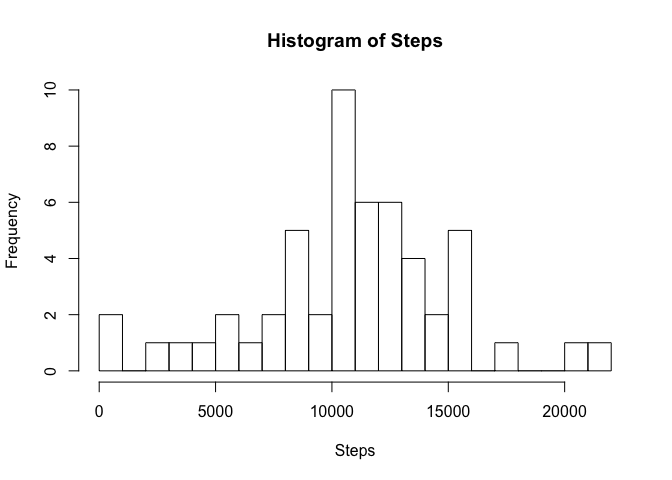

```r
hist(steps$steps, main="Histogram of Steps", xlab="Steps", breaks=20)
```

## What is mean total number of steps taken per day?

```r
mean(steps$steps)
```

```
## [1] 10766.19
```

## What is the median total number of steps taken per day?

```r
median(steps$steps)
```

```
## [1] 10765
```

## What is the average daily activity pattern?

Aggregating data by intervals:

```r
steps2<-aggregate(steps ~ interval, data=activity, sum)
```

Averaging out over the number of days:

```r
steps2$stepsavg<-steps2$steps / nrow(steps)
```

Plotting the timeseries of the average daily activity:

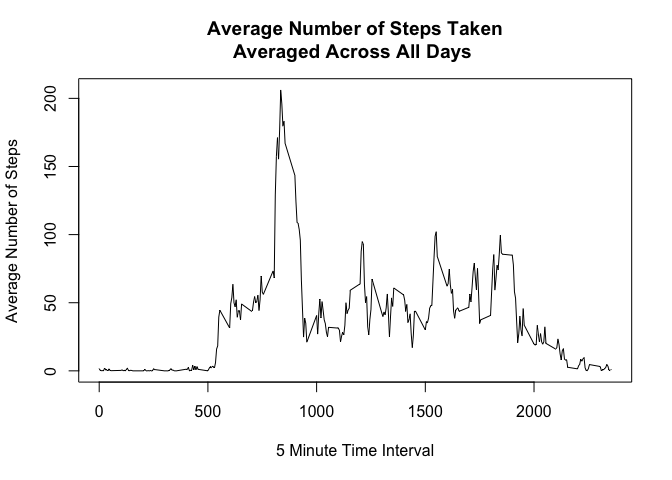

```r
plot(x=steps2$interval, y=steps2$stepsavg, type="l", xlab="5 Minute Time Interval", ylab="Average Number of Steps", main="Average Number of Steps Taken\nAveraged Across All Days ")
```

Getting the max interval averaged out over all days:

```r
stepssorted<-steps2[order(steps2$stepsavg),]
tail(stepssorted, n=1)
```

```
##     interval steps stepsavg
## 104      835 10927 206.1698
```

## Imputing missing values

Calculating the number of NA values in steps for the activity DF:

```r
sum(is.na(activity$steps))
```

```
## [1] 2304
```

Filling in the missing NA values. The strategy for filling in the missing NA values is to use average values of the intervals calculated above.

Merging the activity and steps2 dataframe into one new one:

```r
activity2<-merge(activity, steps2, by="interval")
```

Subsituting the NAs with average values:

```r
activity2$steps.x[is.na(activity2$steps.x)]<-activity2$stepsavg[is.na(activity2$steps.x)]
```

Cleaning up the dataframe

```r
activity2$steps.y<-NULL
activity2$stepsavg<-NULL
colnames(activity2)<-c("interval","steps","date")
```

## Repeating steps from above with new filled in dataframe

Aggregating steps by date:

```r
steps3<-aggregate(steps ~ date, data=activity2, sum)
```

Using hist to graph a histogram of the number of steps with 20 breaks to get more fine grained:

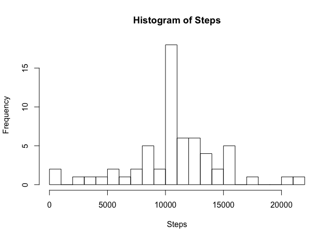

```r
hist(steps3$steps, main="Histogram of Steps", xlab="Steps", breaks=20)
```

Mean steps:

```r
mean(steps3$steps)
```

```
## [1] 10766.19
```

Median steps:

```r
median(steps3$steps)
```

```
## [1] 10766.19
```

Differences between mean:

```r
mean(steps3$steps) - mean(steps$steps)
```

```
## [1] 0
```

Differences between median:

```r
median(steps3$steps)-median(steps$steps)
```

```
## [1] 1.188679
```

## Are there differences in activity patterns between weekdays and weekends?

Using built in R libraries to determine if the date is a weekday or weekend. Sunday and Saturday are defined as weekend days. Then adding that value to the dataframe and converting it to a factor value:

```r
dow<-weekdays(as.POSIXlt(activity2$date))
ss<-ifelse(dow == "Saturday" | dow == "Sunday", "weekend", "weekday")
activity2$day<-ss
activity2$day<-factor(activity2$day)
```

Using ddply to aggregate and mean the steps per interval across the weekends and weekdays:

```r
library(plyr)
steps4<-ddply(activity2, c("day","interval"), summarize, mean=mean(steps))
```

Using the lattice library to draw a time series panel plot:

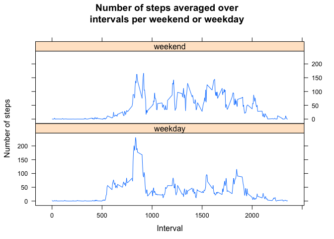

```r
library(lattice)
xyplot(mean ~ interval| day,
       data = steps4,
       type = "l",
       xlab = "Interval",
       ylab = "Number of steps",
       main = "Number of steps averaged over\nintervals per weekend or weekday",
       layout=c(1,2),)
```